# Step 1: load Prepared data

```python
import pandas as pd
import matplotlib.pyplot as plt
import seaborn as sns
```

```python
sns.set(style="whitegrid")
plt.rcParams['figure.figsize'] = (12,6)

# load the cleaned data
df = pd.read_csv("Cleaned_fitness_classes_data.csv")


print(df.shape)
print(df.head())
print(df.info())
```

```
(3271, 14)
  Site_ID               Class_Name   End_Date Start_Time  Capacity  Booked  \
0     HXP  20-20-20  2.45pm-3.45pm   8-Apr-18   14:45:00        25      12
1     HXP  20-20-20  2.45pm-3.45pm  15-Apr-18   14:45:00        25      15
2     HXP  20-20-20  2.45pm-3.45pm  22-Apr-18   14:45:00        25      14
3     HXP  20-20-20  2.45pm-3.45pm  29-Apr-18   14:45:00        25       9
4     HXP  20-20-20  2.45pm-3.45pm   6-May-18   14:45:00        25       7

   Price_INR End_DateTime Weekday  Hour  Capacity_Utilization  Revenue  \
0      499.0   2018-04-08  Sunday    14                  48.0   5988.0
1      499.0   2018-04-15  Sunday    14                  60.0   7485.0
2      499.0   2018-04-22  Sunday    14                  56.0   6986.0
3      499.0   2018-04-29  Sunday    14                  36.0   4491.0
4      499.0   2018-05-06  Sunday    14                  28.0   3493.0

   MaxBookes Dataset
0         25   Train
1         25   Train
2         25   Train
3         25   Train
4         25   Train
<class 'pandas.core.frame.DataFrame'>
RangeIndex: 3271 entries, 0 to 3270
Data columns (total 14 columns):
 #   Column                Non-Null Count  Dtype
---  ------                --------------  -----
 0   Site_ID               3271 non-null   object
 1   Class_Name            3271 non-null   object
 2   End_Date              3271 non-null   object
 3   Start_Time            3271 non-null   object
 4   Capacity              3271 non-null   int64
 5   Booked                3271 non-null   int64
 6   Price_INR             3271 non-null   float64
 7   End_DateTime          3271 non-null   object
 8   Weekday               3271 non-null   object
 9   Hour                  3271 non-null   int64
 10  Capacity_Utilization  3271 non-null   float64
 11  Revenue               3271 non-null   float64
 12  MaxBookes             3271 non-null   int64
 13  Dataset               3271 non-null   object
dtypes: float64(3), int64(4), object(7)
memory usage: 357.9+ KB
None
```

## Data Summary

The dataset has 3,271 entries and 14 columns, including booking, price, capacity, and time details. There is no missing data, so analysis can proceed without data imputation.

# Step 2: Descriptive Analysis

```python
#Basics Statistics
print(df.describe())

#Distribution of bookings
print("Mean booked:", df["Booked"].mean())
print("Median booked:", df["Booked"].median())
print("Standard deviation:", df["Booked"].std())
```

```
          Capacity       Booked    Price_INR         Hour  \
count  3271.000000  3271.000000  3271.000000  3271.000000
mean     32.224396    17.125955  1852.714460    13.370223
std      15.121398     9.515352   792.636673     3.920957
min       2.000000     1.000000   499.000000     6.000000
25%      24.000000    10.000000  1299.000000    10.000000
50%      30.000000    16.000000  1499.000000    12.000000
75%      35.000000    24.000000  2499.000000    17.000000
max      70.000000    64.000000  3999.000000    20.000000

       Capacity_Utilization        Revenue    MaxBookes
count           3271.000000    3271.000000  3271.000000
mean              57.232947   30288.468664    32.224396
std               31.906499   20363.598835    15.121398
min                1.670000     999.000000     2.000000
25%               34.290000   14990.000000    24.000000
50%               55.560000   26982.000000    30.000000
75%               80.000000   41979.000000    35.000000
max              516.670000  134955.000000    70.000000
Mean booked: 17.125955365331702
Median booked: 16.0
Standard deviation: 9.515352256194983
```

# Step 3: Demand Over Time

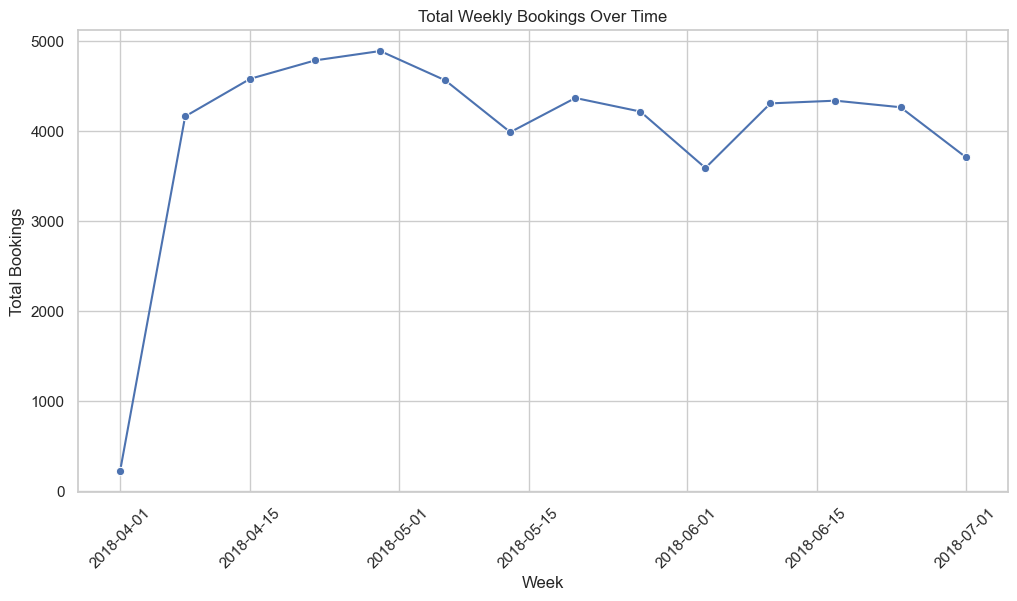

```python
# Convert End_Date to datetime (if not already)
df["End_Date"] = pd.to_datetime(df["End_Date"])

# Group by week
weekly_bookings = df.groupby(pd.Grouper(key="End_Date", freq="W"))["Booked"].sum().reset_index()

# Plot
plt.figure(figsize=(12,6))
sns.lineplot(data=weekly_bookings, x="End_Date", y="Booked", marker="o")
plt.title("Total Weekly Bookings Over Time")
plt.xlabel("Week")
plt.ylabel("Total Bookings")
plt.xticks(rotation=45)
plt.show()
```

# Step 4: Weekday Analysis

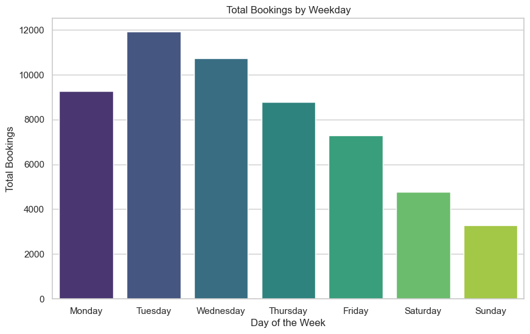

```python
# Group by weekday
weekday_bookings = df.groupby("Weekday")["Booked"].sum().reindex(
    ["Monday", "Tuesday", "Wednesday", "Thursday", "Friday", "Saturday", "Sunday"]
).reset_index()

# Plot
plt.figure(figsize=(10,6))
sns.barplot(data=weekday_bookings, x="Weekday", y="Booked", palette="viridis")
plt.title("Total Bookings by Weekday")
plt.xlabel("Day of the Week")
plt.ylabel("Total Bookings")
plt.show()
```

# Step 6: Class Popularity Analysis

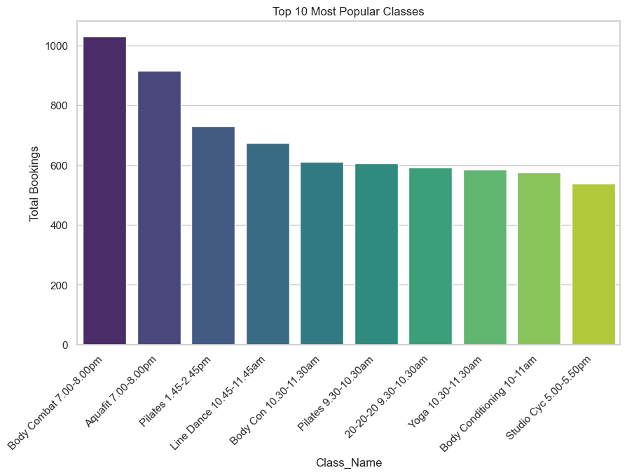

```python
# Top 10 classes by total bookings
top_classes = class_bookings.head(10)

plt.figure(figsize=(10,6))
sns.barplot(data=top_classes, x="Class_Name", y="Booked", palette="viridis")
plt.title("Top 10 Most Popular Classes")
plt.xticks(rotation=45, ha="right")
plt.ylabel("Total Bookings")
plt.show()
```

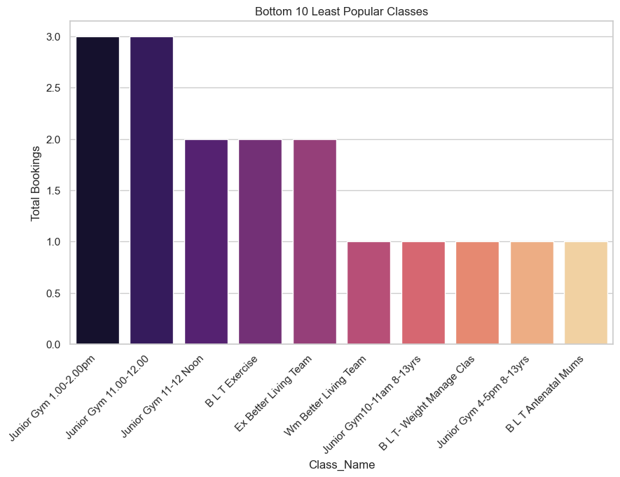

```python
# Bottom 10 classes by total bookings
bottom_classes = class_bookings.tail(10)

plt.figure(figsize=(10,6))
sns.barplot(data=bottom_classes, x="Class_Name", y="Booked", palette="magma")
plt.title("Bottom 10 Least Popular Classes")
plt.xticks(rotation=45, ha="right")
plt.ylabel("Total Bookings")
plt.show()
```

# Step7: Capacity Utilization Distribution

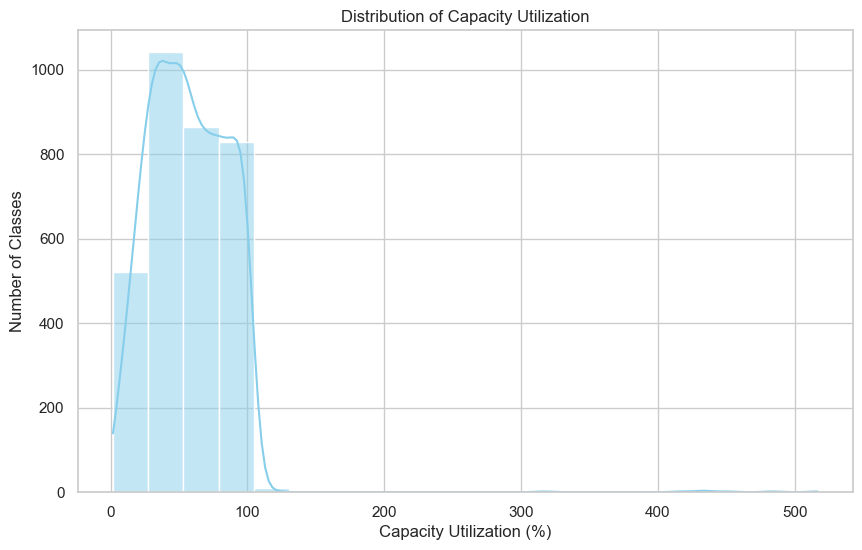

```python
plt.figure(figsize=(10,6))
sns.histplot(df["Capacity_Utilization"], bins=20, kde=True, color="skyblue")
plt.title("Distribution of Capacity Utilization")
plt.xlabel("Capacity Utilization (%)")
plt.ylabel("Number of Classes")
plt.show()
```

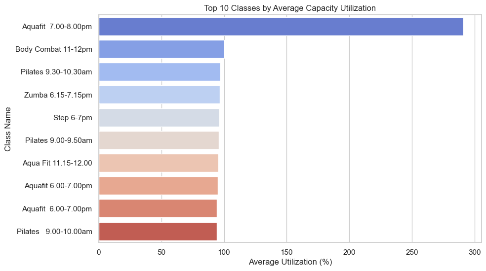

```python
class_utilization = df.groupby("Class_Name")["Capacity_Utilization"].mean().sort_values(ascending=False).head(10)

plt.figure(figsize=(10,6))
sns.barplot(x=class_utilization.values, y=class_utilization.index, palette="coolwarm")
plt.title("Top 10 Classes by Average Capacity Utilization")
plt.xlabel("Average Utilization (%)")
plt.ylabel("Class Name")
plt.show()
```

# Step 8: Revenue Analysis

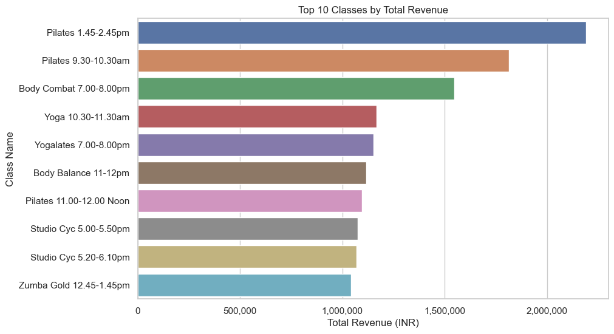

```python
#Revenue by Class (Top 10)
import matplotlib.ticker as mtick
class_revenue = df.groupby("Class_Name")["Revenue"].sum().sort_values(ascending = False).head(10)
# print(class_revenue)
plt.figure(figsize=(10, 6))
sns.barplot( x = class_revenue.values, y = class_revenue.index, hue = class_revenue.index, legend = False)
plt.title("Top 10 Classes by Total Revenue")
plt.xlabel("Total Revenue (INR)")
plt.ylabel("Class Name")
plt.gca().xaxis.set_major_formatter(mtick.StrMethodFormatter('{x:,.0f}'))
plt.show()
```

# Step 9: Revenue Trends Over Time

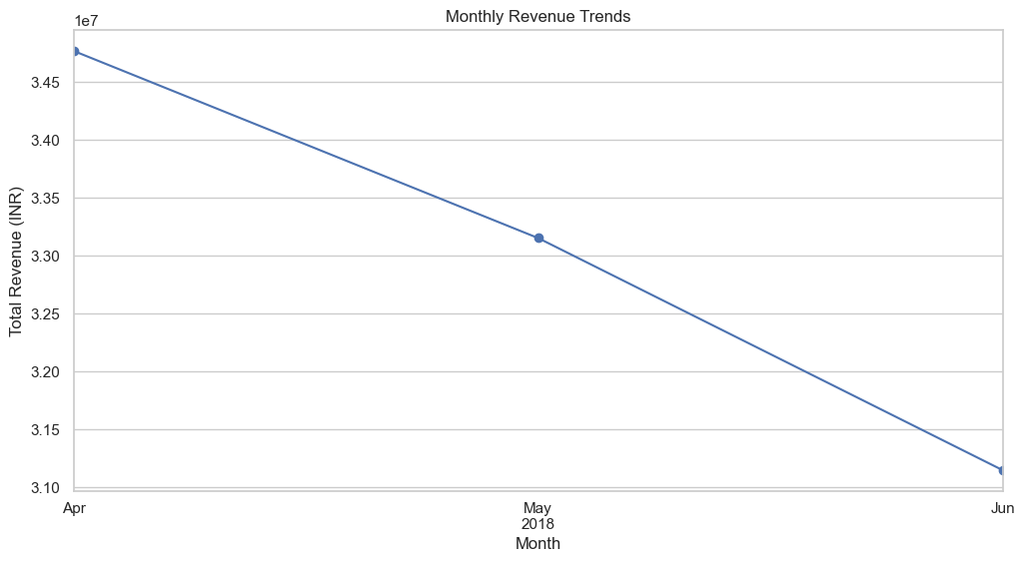

```python
monthly_revenue = df.groupby(df["End_Date"].dt.to_period("M"))["Revenue"].sum()

plt.figure(figsize=(12,6))
monthly_revenue.plot(marker="o")
plt.title("Monthly Revenue Trends")
plt.xlabel("Month")
plt.ylabel("Total Revenue (INR)")
plt.xticks(rotation=45)
plt.show()
```

# Step 10: Price vs Utilization Relationship

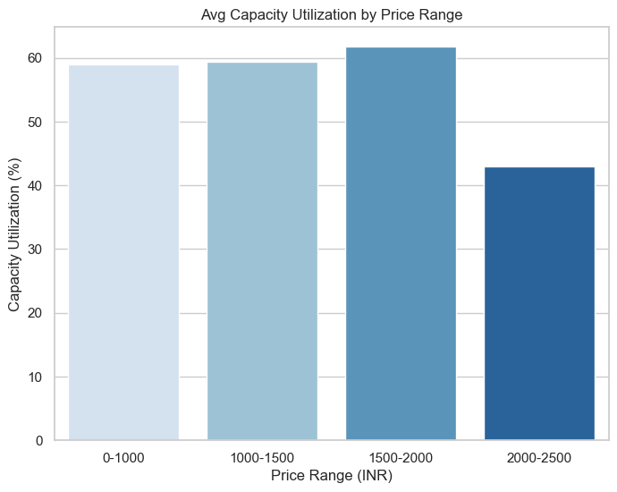

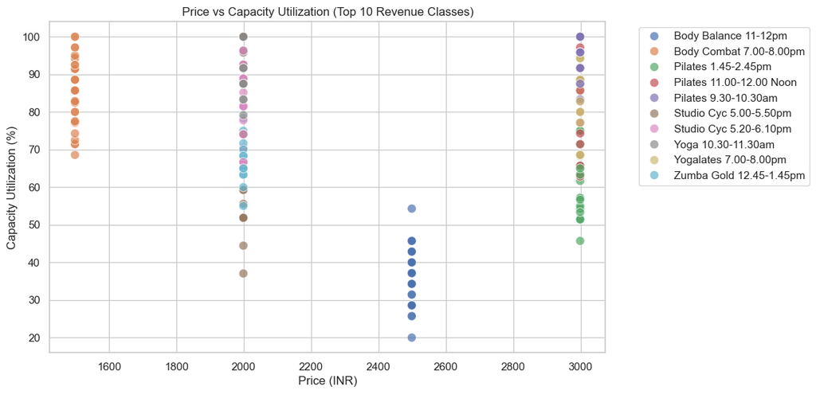

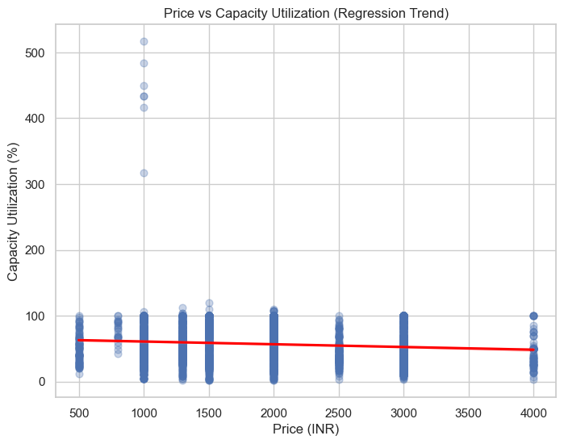

```python
df["Price_Range"] = pd.cut(
    df["Price_INR"],
    bins=[0, 1000, 1500, 2000, 2500],
    labels=["0-1000", "1000-1500", "1500-2000", "2000-2500"]
)

price_util = df.groupby("Price_Range")["Capacity_Utilization"].mean().reset_index()

plt.figure(figsize=(8,6))
sns.barplot(data=price_util, x="Price_Range", y="Capacity_Utilization", palette="Blues")
plt.title("Avg Capacity Utilization by Price Range")
plt.ylabel("Capacity Utilization (%)")
plt.xlabel("Price Range (INR)")
plt.show()


# ------------------------------------------------------------
# 2. Top 10 Classes by Revenue (Price vs Utilization)
# ------------------------------------------------------------
top_classes = (
    df.groupby("Class_Name")["Revenue"]
    .sum()
    .sort_values(ascending=False)
    .head(10)
    .index
)

df_top = df[df["Class_Name"].isin(top_classes)]

plt.figure(figsize=(10,6))
sns.scatterplot(
    data=df_top,
    x="Price_INR",
    y="Capacity_Utilization",
    hue="Class_Name",
    alpha=0.7,
    s=80
)
plt.title("Price vs Capacity Utilization (Top 10 Revenue Classes)")
plt.xlabel("Price (INR)")
plt.ylabel("Capacity Utilization (%)")
plt.legend(bbox_to_anchor=(1.05, 1), loc="upper left")
plt.show()


# ------------------------------------------------------------
# 3. Regression (General Trend Across All Classes)
# ------------------------------------------------------------
plt.figure(figsize=(8,6))
sns.regplot(
    data=df,
    x="Price_INR",
    y="Capacity_Utilization",
    scatter_kws={"alpha":0.3, "s":40},
    line_kws={"color":"red"}
)
plt.title("Price vs Capacity Utilization (Regression Trend)")
plt.xlabel("Price (INR)")
plt.ylabel("Capacity Utilization (%)")
plt.show()
```

# Overall Story from these graphs:

Premium classes (₹2000+) earn revenue but don’t fill as well → so they rely on fewer people paying higher prices.

For future pricing strategy → keep a mix:

Affordable classes to keep utilization high.

A few premium classes for revenue, but don’t overprice most classes.

# Step 11: Day-of-Week Analysis

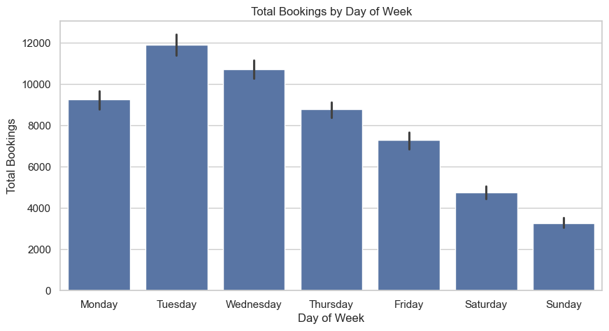

```python
plt.figure(figsize=(10,5))
sns.barplot(data=df, x="Weekday", y="Booked", estimator="sum",
            order=["Monday","Tuesday","Wednesday","Thursday","Friday","Saturday","Sunday"])
plt.title("Total Bookings by Day of Week")
plt.xlabel("Day of Week")
plt.ylabel("Total Bookings")
plt.show()
```

# Step 12: Time-of-Day Analysis

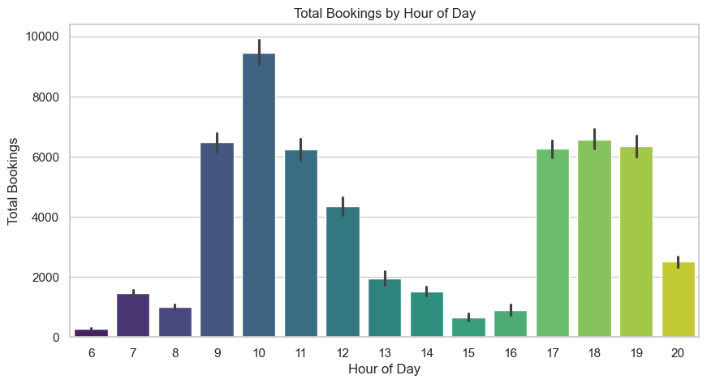

```python
plt.figure(figsize=(10,5))
sns.barplot(data=df, x="Hour", y="Booked", estimator="sum", palette="viridis")
plt.title("Total Bookings by Hour of Day")
plt.xlabel("Hour of Day")
plt.ylabel("Total Bookings")
plt.show()
```

# Step 13: Correlation Heatmap

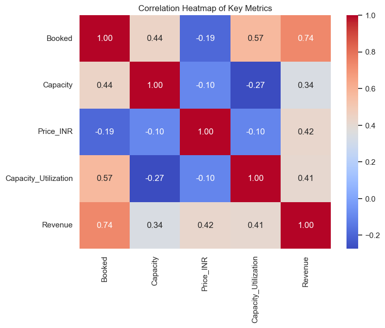

```python
plt.figure(figsize=(8,6))
sns.heatmap(df[["Booked","Capacity","Price_INR","Capacity_Utilization","Revenue"]].corr(),
            annot=True, cmap="coolwarm", fmt=".2f")
plt.title("Correlation Heatmap of Key Metrics")
plt.show()
```

# Step 14: Outlier Detection (Attendance & Price)

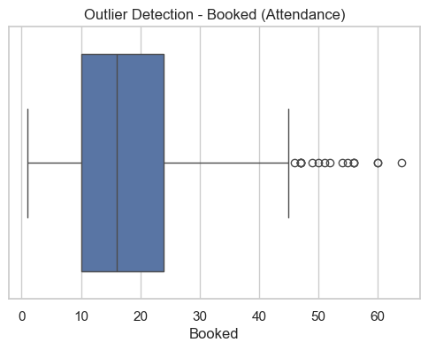

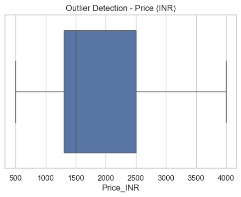

```python
# Outliers in Booked (attendance)
plt.figure(figsize=(6,4))
sns.boxplot(x=df['Booked'])
plt.title("Outlier Detection - Booked (Attendance)")
plt.show()

# Outliers in Price
plt.figure(figsize=(6,4))
sns.boxplot(x=df['Price_INR'])
plt.title("Outlier Detection - Price (INR)")
plt.show()
```

# Step 15: Attendance by Location

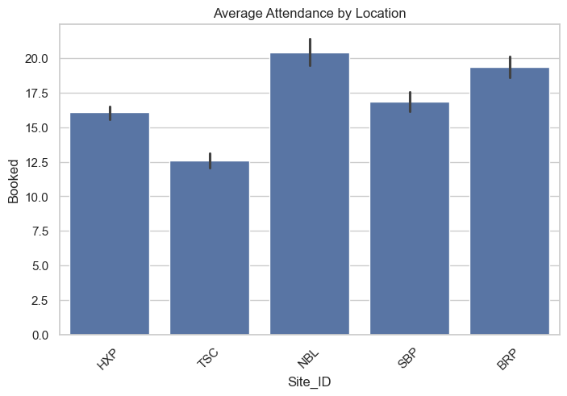

```python
plt.figure(figsize=(8,5))
sns.barplot(x="Site_ID", y="Booked", data=df, estimator="mean")
plt.title("Average Attendance by Location")
plt.xticks(rotation=45)
plt.show()
```

## Key Insights from EDA

1. Overall Demand & Descriptive Stats

   · Dataset includes 3,271 entries with 14 columns (bookings, price, utilization, revenue, etc.).

   · Average bookings per class show high variance - some classes are consistently full, others underutilized.
2. Demand Over Time

   . Least popular classes show very low bookings - candidates for price discounts or removal from schedule.
5. Capacity Utilization

   . Many classes run below 50% utilization - wasted capacity.

   · Top classes achieve >80% utilization, mostly in premium times (mornings, evenings).

   . Indicates that pricing strategy should aim to shift demand to underutilized slots.
6. Revenue Analysis

   · Some less popular classes still generate revenue due to premium pricing, but their utilization is weak.

   · Suggests revenue is disproportionately dependent on a few class types.
7. Revenue Trends Over Time

   . Dynamic pricing could stabilize revenue by smoothing out dips.
8. Price vs Utilization Relationship

   · Premium classes (₹2000+) earn revenue but attract fewer participants.

   · Clear case for a mixed pricing model:

   ```
    · Affordable classes - drive volume/utilization.


    · Premium classes - maintain exclusivity and margin.
   ```

9. Day-of-Week Demand

   · Confirms earlier weekday trend: demand peaks midweek, dips on Fridays/weekends.

   · Suggests weekday premiums and weekend discounts as part of pricing rules.